# Partisan Podcasts

## Goal

To categorize the top US news podcasts on Spotify based on political alignment.

```python
import pickle
import time
import requests
from selenium import webdriver
from selenium.webdriver.chrome.options import Options
from selenium.webdriver.common.keys import Keys
from selenium.webdriver.common.by import By
from selenium.webdriver.support.ui import WebDriverWait
from selenium.webdriver.support import expected_conditions as EC
from bs4 import BeautifulSoup
import re
import numpy as np
import matplotlib
import matplotlib.pyplot as plt
import pandas as pd

# turn on latex for matplotlib
# matplotlib.rc('text', usetex=True)
# matplotlib.rcParams['text.latex.preamble']=r"\usepackage{amsmath}"

# Useful functions/definitions
def remove_spines(ax, sides=["top", "right"]):
    """
    Removes spines from all graphs in given axis. Works with an individual axis or list of axes.
    By default removes top and right spines. Returns ax.
    """
    for side in sides:
        try:
            for a in ax:
                a.spines[side].set_visible(False)
        except:
            ax.spines[side].set_visible(False)
    return ax
facecolor=(245/255, 245/255, 245/255)
```

### Find Data

Find [Chartable's Top 50 News Podcasts on Spotify](https://chartable.com/charts/spotify/united-states-of-america-news-politics) for the current day and place in a dataframe.

```python
# Extract top 50 news podcasts, according to the spotify charts
url_pod = "https://chartable.com/charts/spotify/united-states-of-america-news-politics"
options = Options()
options.add_argument("--headless")
driver = webdriver.Chrome("C:/Users/ncris/econ/chromedriver_win32/chromedriver.exe", options=options)
driver.get(url_pod)
soup_pod = BeautifulSoup(driver.page_source, "lxml")
driver.close()

pod_details = [] # appended in order
pod_table = soup_pod.body.find("table")
for row in pod_table.find_all("tr"):
#     number = row.find("div", {"class" : "b header-font f2 tc"}).text
    description = row.find("td", {"class" : "pv2 ph1"}).text
    pod_details.append(description[1:-1].split("\n"))
pod_details
pod_df = pd.DataFrame(pod_details, columns=["Source", "Name"])
# Replace None values in podcast name with the source of the podcast
pod_df.loc[pod_df["Name"].isnull(), "Name"] = pod_df.loc[pod_df["Name"].isnull(), "Source"]
pod_df.head()
```

|  | Source | Name |
| --- | --- | --- |
| 0 | Breaking Points with Krystal and Saagar | Breaking Points with Krystal and Saagar |
| 1 | The New York Times | The Daily |
| 2 | NPR | Up First |
| 3 | The Daily Wire | The Ben Shapiro Show |
| 4 | NPR | On Our Watch |

### Find Partisan Leans

Because not all podcasts in the news category are politically-focused, I want to drop non-political podcasts, which I originally thought could be done through examining their descriptions on Spotify. My thought was that I could parse through these descriptions, but realized that it's very difficult; there's a large variance in description content, with some shorter and less informative and others long paragraphs. Perhaps using some sort of natural language classification could help? But if I wanted to do that, it would require much more data to train the algorithms on (would need to use episode descriptions), and isn't necessarily going to be accurate. No matter what, I will need to look at the data myself, due to my desire to classify all data sources correctly. Because a large number of the podcasts stay in the top charts, this isn't too tedious. Besides, someone needs to create a centralized list of partisan podcast leans, so why not I?

I will use the internet to find political leans. Using [AllSides](https://www.allsides.com/media-bias/media-bias-ratings) ratings, I'll rate each podcast's partisan lean using their source or name. I will then supplement these ratings with my own categorizations.

```python
# Clean Media
def clean_names(names):
    """
    Removes filler words from name list so allsides can easily search.
    Returns altered list.
    """
    # deep copy
    name_list = [n for n in names]
    # remove filler words from source list so allsides can easily search
    abbrev_re = re.compile(r"([A-Z]{2,})")
    for i in range(len(name_list)):
        # remove 'podcasts', 'networks', 'the' from name
        name_list[i] = re.sub(r"[Pp]odcasts?|[Nn]etworks?|\s?[Tt]he\s?|[Oo]pinion", "", name_list[i])
        # if there's an abbreviation in all caps (more than two capital letters next to each other,
        # replace name str with abbreviation
        abbrev = re.findall(abbrev_re, name_list[i])
        if len(abbrev) > 0:
            name_list[i] = abbrev[0]
        name_list[i] = name_list[i].strip()
    return name_list


def find_biases_dict(source_list, partisan_leans):
    """
    Takes a list of strings and finds their corresponding partisan lean according to allsides.com
    and/or the dictionary provided.
    If there is no partisan lean, the value is not placed in the dictionary.
    Returns given dictionary with the keys as the source names and the values as the partisan leans.
    """
    source_list_use = clean_names(source_list)
    driver = webdriver.Chrome("C:/Users/ncris/econ/chromedriver_win32/chromedriver.exe", options=options)
    ratings_url = "https://www.allsides.com/media-bias/media-bias-ratings"
    driver.get(ratings_url)
    for source, source_full in zip(source_list_use, source_list):
        # if source not already in dict
        if partisan_leans.get(source_full) == None:
            # find input and type source
            # Waits 10 seconds until element with id "edit-title" is found -- if it's not or time passes, throws error
            input_element = WebDriverWait(driver, 10).until(EC.presence_of_element_located((By.ID, "edit-title")))
    #         input_element = driver.find_element_by_id("edit-title")
            input_element.clear()
            input_element.send_keys(source, Keys.RETURN)
            ratings_soup = BeautifulSoup(driver.page_source, "lxml")
            try:
                ratings_table = ratings_soup.find("table", {"class", "views-table cols-4"})
                source_name = ratings_table.find("td", {"class", "views-field views-field-title source-title"}).text
                rating = ratings_table.find("td", {"class", "views-field views-field-field-bias-image"}).find("img").get("title").strip()
                # add last word of AllSides rating to dict, which is of form AllSides Media Bias Rating: _____ (or lean _____)
                # keys of dict are full names of source, not cleaned names
                partisan_leans[source_full] = rating.split(" ")[-1]
            except:
                pass
        # wait before next round
        time.sleep(0.1)
    driver.close()
    return partisan_leans

# quick test with empty dict
find_biases_dict(["The Daily Wire", "The New York Times", "The New York Times Opinion", "NPR", "NPR"], dict())
```

```
{'The Daily Wire': 'Right',
 'The New York Times': 'Left',
 'The New York Times Opinion': 'Left',
 'NPR': 'Center'}
```

Since not all sources can be found using AllSides, I will look through the sources/shows and label the remaining ones myself. This is the only way to guarantee all labels are correct. Perhaps I could classify shows based on their descriptions/show descriptions, but politically-affiliated words like 'leftist' could be used by any kind of show, not just left-leaning shows. There are no other websites that I can find that maintain a list of podcast biases. I give a description for my labeling after each show. Here are the relevant links, in order (this is preliminary; it will hopefully be re-tooled and nicely presented to the user on my website):

Right

- https://en.wikipedia.org/wiki/Dan_Bongino
- https://gasdigitalnetwork.com/gdn-show-channels/part-of-the-problem/
- https://en.wikipedia.org/wiki/Hodgetwins

Left

- https://en.wikipedia.org/wiki/Crooked_Media
- https://en.wikipedia.org/wiki/Chapo_Trap_House
- https://open.spotify.com/show/5uKAwUEZun3X9NyxnwfS7e (Fear & Malding)
- https://en.wikipedia.org/wiki/Bill_Maher#Politics

- https://en.wikipedia.org/wiki/Megyn_Kelly (Devil May Care Media founded by Megyn Kelly)
- https://en.wikipedia.org/wiki/Axios_(website)

```python
# lists known companies and/or names and their ratings--either Left, Right, or Center
# some need to be hard-coded in as they are very difficult to find
# need to alert myself--if there's new podcast on charts that isn't classified--in some way
partisan_database = dict()
names_classify = []
right_names = [["The Realignment", # Hosts Saagar Enjeti and Marshall Kosloff both describe themselves as right-of-center;
                                    # though they (at least Saagar) may be more populist,
                                    # they still hold views better aligned with conservatives
                "Dan Bongino", # ran for Congress as republican
                "Mark Levin", # Fox News contributor and worked in Reagan white house
                "Fearless with Jason Whitlock", # on The Blaze
                "Office Hours with Georgia Howe", # on The Daily Wire
                "Part Of The Problem", # hosted by self-described libertarian
                "Soundfront", # "Soundfront is a subsidiary of Abbson, a top conservative media company"
                "Hodgetwins"], # self-proclaimed conservatives
               "Right"]
left_names = [["Crooked Media", # created by Obama staffers
               "Real Time with Bill Maher", # Bill Maher has a left-lean; against cancel-culture but still a progressive
               "Chapo Trap House", # self-described far-left
               "QAnon Anonymous", # explores QAnon theory; will inherently have leftist lean
               "Krystal Kyle & Friends", # Hosts Krystal Ball and Kyle Kulinski are self-described progressives
               "Fear & Malding", # self-described as left-leaning podcast
               "Q Clearance: The Hunt for QAnon"], # explores QAnon theory; will inherently have leftist lean
              "Left"]
center_names = [["Breaking Points with Krystal and Saagar", # Hosts Krystal Ball and Saagar Enjeti both populists
                                                              # but the former leans left and the latter leans right
                                                              # even though they aren't the center, placed for  ease of categorization
                  "Devil May Care Media", # Megyn Kelly is self-described independent
                  "Axios & Pushkin Industries"], # most readers moderate, slightly left-leaning but not entirely
                                                    # so I'll put it as neither
                 "Center"]
names_classify.extend([right_names, left_names, center_names])
# Iterates through each name & partisan lean pair and adds to dictionary
for nc in names_classify:
    for n in nc[0]:
        partisan_database[n] = nc[1]

# add AllSides ratings to partisan_database
pod_companies = list(pod_df["Source"].values)
pod_names = list(pod_df["Name"].values)

find_biases_dict(pod_companies + pod_names, partisan_database)
# show sample 5 elements from partisan_database dict:
dict(list(partisan_database.items())[:5])
```

```
{'The Realignment': 'Right',
 'Dan Bongino': 'Right',
 'Mark Levin': 'Right',
 'Fearless with Jason Whitlock': 'Right',
 'Office Hours with Georgia Howe': 'Right'}
```

```python
# To save
# with open('partisan_database.pkl', 'wb') as f:
#     pickle.dump(partisan_database, f)

# To reload
# with open('partisan_database.pkl', 'rb') as f:
#     partisan_database = pickle.load(f)
```

### Classify Podcasts

Create dataframe with partisan leans assigned to each podcast.

```python
def categorize_leans(pod_bias_df, partisan_database):
    '''
    Categorize each row of pod_bias_df based on partisan leans stored in partisan_database dict.
    If unable to label, classify as "Neither".
    Will add new column named "Partisan Leans" to store the data.
    Returns modified df.
    '''
    # For show names like 'The Dan Bongino Show'
    isolate_name = re.compile(r"^[Tt]he\s+|\S?[Ss]how\S?|\S?[Pp]odcast\S?")
    for index, row in pod_bias_df.iterrows():
        # Clean names -- spotify charts has title formatting
        channel_class = partisan_database.get(row[0].strip())
        name_class = partisan_database.get(re.sub(isolate_name, "", row[1]).strip())
        # labels by podcast name first, if possible, then by channel name
        if name_class != None:
            pod_bias_df.loc[index, "Partisan Lean"] = name_class
        elif channel_class != None:
            pod_bias_df.loc[index, "Partisan Lean"] = channel_class
        else:
            pod_bias_df.loc[index, "Partisan Lean"] = "Neither"
    return pod_bias_df

pod_bias_df = pod_df.copy() # preserve original dataframe for ease of editing
categorize_leans(pod_bias_df, partisan_database)
pod_bias_df.head()
```

|  | Source | Name | Partisan Lean |
| --- | --- | --- | --- |
| 0 | Breaking Points with Krystal and Saagar | Breaking Points with Krystal and Saagar | Center |
| 1 | The New York Times | The Daily | Left |
| 2 | NPR | Up First | Center |
| 3 | The Daily Wire | The Ben Shapiro Show | Right |
| 4 | NPR | On Our Watch | Center |

Give list of 'Neither' to inspect; allow user to see if anything is miscategorized as nonpolitical.

```python
pod_bias_df.query("`Partisan Lean` == 'Neither'")
```

|  | Source | Name | Partisan Lean |
| --- | --- | --- | --- |
| 10 | Serial Productions | Serial | Neither |
| 11 | Robinhood Financial, LLC | Snacks Daily | Neither |
| 39 | The Center for Investigative Reporting and PRX | Reveal | Neither |
| 43 | APM Reports | In the Dark | Neither |
| 45 | Seeking Alpha | Wall Street Breakfast | Neither |

Since the podcasts are now categorized, I will create a plot for the current day.

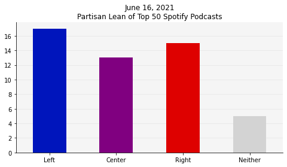

```python
from datetime import date
today_date = date.today().strftime('%B %d, %Y')
today_date_short = date.today().strftime('%b%d%y')
fig, ax = plt.subplots(figsize=(8, 4))
colors = ["#0015BC", "purple", "#DE0100", "lightgrey"]
(pod_bias_df.groupby("Partisan Lean")["Source"].count()[["Left", "Center", "Right", "Neither"]]
.plot(ax=ax, kind="bar", color=colors, title=f"{today_date}\nPartisan Lean of Top 50 Spotify Podcasts",
      xlabel="", zorder=2) # place above grid
)
remove_spines(ax)
# ax.tick_params(axis="y", left=False, labelleft=True)
ax.grid(axis="y", alpha=0.2)
ax.tick_params(axis="x", labelrotation=0)
ax.set_facecolor(facecolor)
# fig.savefig(f"podcast_leans_{today_date_short}.png", dpi=200)
```

### Analysis

Looks like a fairly even distribution!

Later, they could look at intra-category distributions (e.g., progressive vs. neoliberal, lean-left vs. independent, etc.) or other useful stats (self-funded or corporate sponsor?)

Let's store this in a file, so I can make comparisons across time. I will be using HDF storage, with each day's dataframe added with a key like "Jun1621" (datetime format of "%b%d%y").

```python
# testing
# df1 = pd.DataFrame({'col1': [2, 4], 'col2': [5, 8]})
# df1.to_hdf('test.h5', key='df1', mode='w')
# df2 = pd.DataFrame({'col1': [1, 4, 3], 'col2': [2, 3, 8]})
# df2.to_hdf('test.h5', key='df2', mode='a')
# pd.read_hdf('test.h5', key='df2')

# append current day's dataframe to file (test)
# pod_bias_df.to_hdf("podcasts.h5", key=f"{today_date_short}", mode="a")

# read current day's dataframe from file (test)
# pd.read_hdf("podcasts.h5", key=f"{today_date_short}")

# read from batch file's creation to check if works
pd.read_hdf("../ncrispino.github.io/spotify_podcasts.h5", key=f"{today_date_short}").head()
```

[output not shown]

## References

- [Chartable](https://chartable.com/)
- [AllSides](https://www.allsides.com/unbiased-balanced-news)

  ```
  Creative Commons License: http://creativecommons.org/licenses/by-nc/4.0/

  AllSides Media Bias Ratings™ by AllSides.com are licensed under a Creative Commons Attribution-NonCommercial 4.0 International License. These ratings may be used for research or noncommercial purposes with attribution.
  ```